# Uvod u vizualizaciju podataka u R-u - Vežbe

### Legenda

https://www.datanovia.com/en/blog/ggplot-legend-title-position-and-labels/

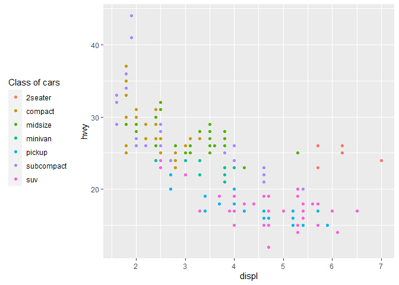

```r
base <- ggplot(mpg, aes(displ, hwy)) +
  geom_point(aes(colour = class))+
  labs(colour = "Class of cars")

base + theme(legend.position = "left")
```

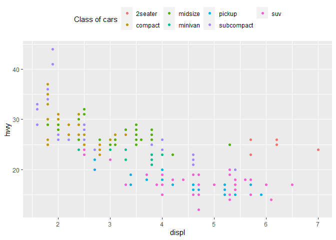

```r
base + theme(legend.position = "top")
```

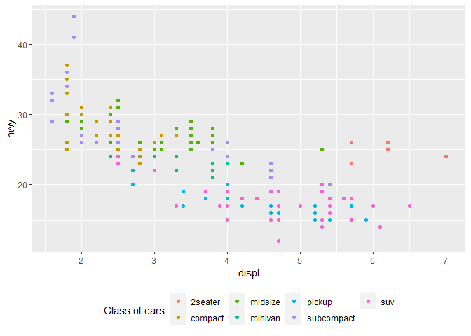

```r
base + theme(legend.position = "bottom")
```

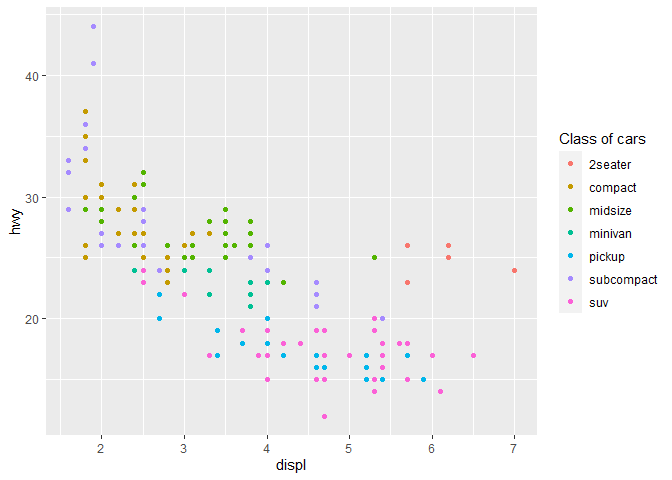

```r
base + theme(legend.position = "right")
```

+theme(legend.position = “none”) - na ovaj način ne prikazujemo legendu podataka

Isto tako kao što definišemo razmeru osa, odnos boja kojima prikazujemo podatke je bitan i često imamo predefinisane klase boja kojima želimo da prikažemo podake. Postoje i paketi kojima možemo da kreiramo paletu boja po želji, kako za kontinualne tako i za diskretne podatke.

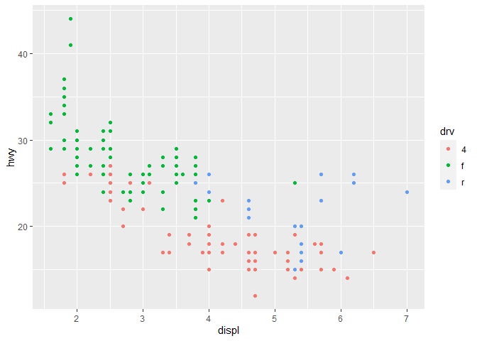

```r
ggplot(mpg, aes(displ, hwy)) +
  geom_point(aes(color = drv))
```

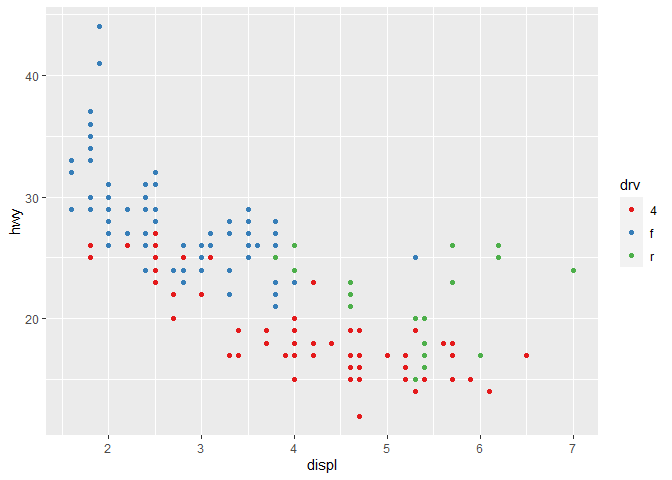

```r
ggplot(mpg, aes(displ, hwy)) +
  geom_point(aes(color = drv)) +
  scale_colour_brewer(palette = "Set1")
```

paket “viridis” nudi veoma kvalitetne palete boja, pre svega za kontinualne podatke.

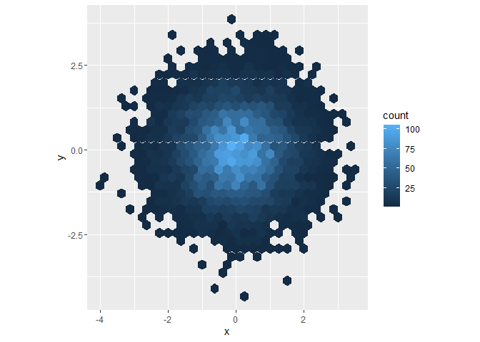

```r
df <- tibble(
  x = rnorm(10000),
  y = rnorm(10000)
)
ggplot(df, aes(x, y)) +
  geom_hex() +
  coord_fixed()
```

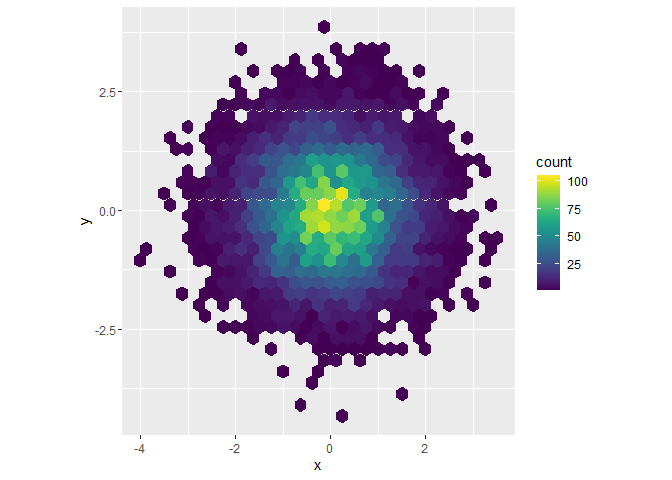

```r
ggplot(df, aes(x, y)) +
  geom_hex() +
  viridis::scale_fill_viridis(option = "D") +
  coord_fixed()
```

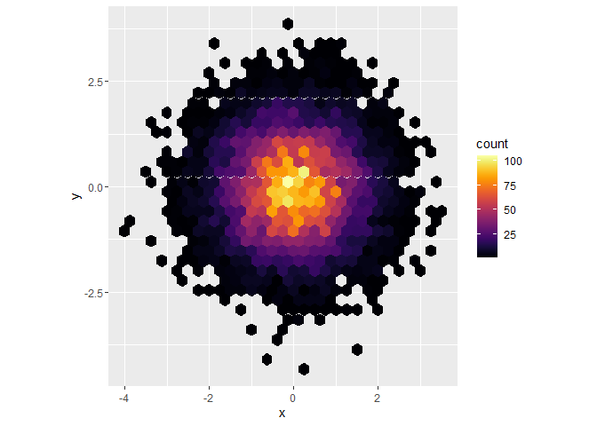

```r
ggplot(df, aes(x, y)) +
  geom_hex() +
  viridis::scale_fill_viridis(option = "B") +
  coord_fixed()
```

### Tema

Bitan element kreiranja grafika je tema, putem koje se definišu parametri i elemnti grafika koji ne sadrže podatke.

Pogledati: https://github.com/jrnold/ggthemes

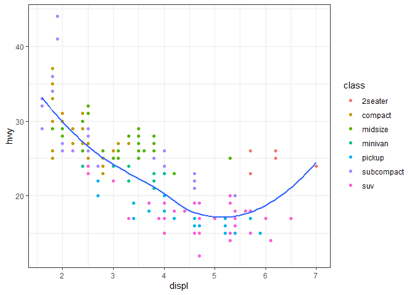

```r
ggplot(mpg, aes(displ, hwy)) +
  geom_point(aes(color = class)) +
  geom_smooth(se = FALSE) +
  theme_bw()
```

### Čuvanje grafika

Grafik čuvamo komandom ggsave, u okviru koje se definišu parametri plot - promenljiva koja sadrži grafik, filename - putanja ka izlaznom fajlu, width - širina grafika, height - visina grafika, units - jedinice u kojima je izražena širina i visina, device - format podataka, dpi - “dots per inch” rezolucija, kvalitet grafika.

```r
graf1 <- ggplot(mpg, aes(displ, hwy)) +
  geom_point(aes(color = class)) +
  geom_smooth(se = FALSE) +
  theme_bw()

ggsave(plot = graf1,
       filename = "D:/R_projects/Nauka_R/Slides/R/graf1.jpg",
       width = 30,
       height = 30,
       units = "cm",
       device = "jpeg",
       dpi = 300)
```